# 02-locus-HWE-evaluation

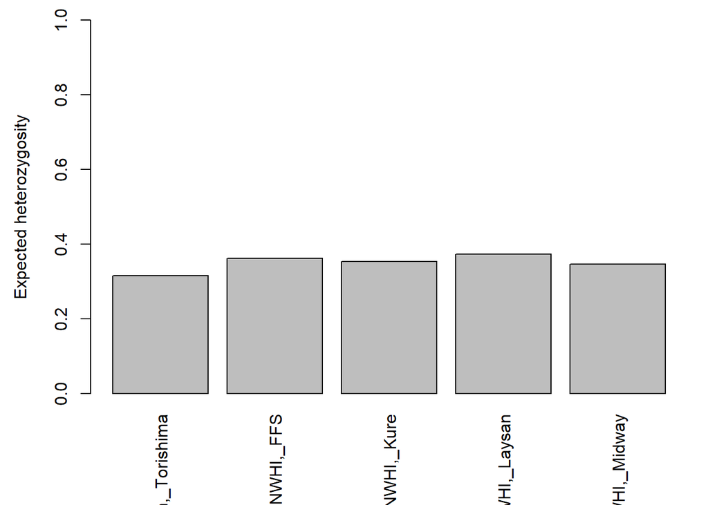

```r
par(mar=c(5.5, 4.5, 1, 1))
  Hobs.pop <- apply(Hobs, MARGIN = 1, FUN = mean)
  Hexp.pop <- apply(Hexp, 1, mean)
  barplot(Hexp.pop, ylim=c(0,1), las=3, ylab="Expected heterozygosity")
```

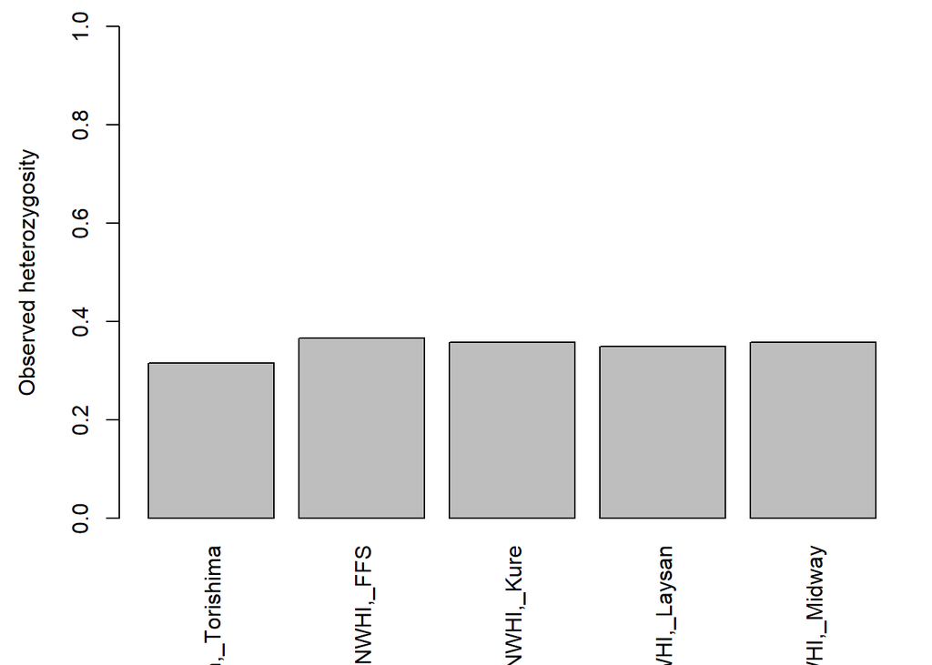

```r
  barplot(Hobs.pop, ylim=c(0,1), las=3, ylab="Observed heterozygosity")
```

```r
bfal_diversity <- data.frame(Pop = names(Hobs.pop),
                              n_samples = sum_output$n.by.pop,
                              Hobs = Hobs.pop,
                              Hexp = Hexp.pop)
                              #Ar = Richness$mean.richness)
as.tibble(bfal_diversity) %>%
  rename(Population = Pop, H_obs = Hobs, H_exp = Hexp) #%>%
```

```
## # A tibble: 5 x 4
##   Population       n_samples H_obs H_exp
##   <chr>                <dbl> <dbl> <dbl>
## 1 Japan,_Torishima        43 0.315 0.316
## 2 NWHI,_FFS               36 0.366 0.363
## 3 NWHI,_Kure              24 0.358 0.353
## 4 NWHI,_Laysan             9 0.349 0.373
## 5 NWHI,_Midway            14 0.358 0.347
```

```r
  #write_csv("csv_outputs/reference_pop_hz_summary.csv")
```

chi^2: value of the classical chi-squared test statistic df: degrees of freedom of the chi-squared test Pr(chi^2 >): p-value of the chi-squared test (‘>’ indicates that the alternative is ‘greater,’ which is always the case for a chi-squared test) Pr.exact: p-value from an exact test based on Monte Carlo permutation of alleles (for diploids only). The default is B = 1000 permutations (set B = 0 to skip this test). Here we use the function ‘round’ with argument ‘digits = 3’ to round all values to 3 decimals.

https://rdrr.io/cran/pegas/man/hw.test.html

In this case, the degrees of freedom depend on the number alleles for a given locus.

```r
# HWE test for all loci - but really what we want is all loci in each population (farther below)
hwe_output <- round(pegas::hw.test(genind_df, B = 1000), digits = 3)
```

[output not shown]

[output cut: 31 more lines]

[output not shown]

```r
# which ones are statistically sign.
rownames_to_column(data.frame(hwe_output)) %>%
  filter(Pr.exact < 0.01)
```

```
##                 rowname   chi.2 df Pr.chi.2... Pr.exact
## 1    scaffold_0_4543438  26.921  6       0.000    0.000
## 2  scaffold_116_1932131   9.560  1       0.002    0.001
## 3  scaffold_123_1115977  14.317  3       0.003    0.000
## 4  scaffold_127_1105814  19.087  6       0.004    0.003
## 5  scaffold_1327_103421 143.357  3       0.000    0.000
## 6   scaffold_155_468225   7.439  1       0.006    0.005
## 7  scaffold_164_1134575  39.078  1       0.000    0.000
## 8  scaffold_185_1133045  11.926  1       0.001    0.001
## 9  scaffold_185_1154507   7.980  1       0.005    0.005
## 10 scaffold_246_1244055   6.829  3       0.078    0.009
## 11  scaffold_306_944429   9.828  1       0.002    0.002
## 12  scaffold_345_694649  13.944  1       0.000    0.000
## 13  scaffold_429_778790   7.503  1       0.006    0.007
## 14  scaffold_51_1220763 253.446  6       0.000    0.001
## 15   scaffold_572_19499 126.000  1       0.000    0.004
## 16  scaffold_582_107987  22.894  1       0.000    0.000
## 17  scaffold_582_222480  17.441  1       0.000    0.000
## 18  scaffold_608_211809 126.000  1       0.000    0.000
## 19  scaffold_612_363793 126.019  3       0.000    0.004
## 20   scaffold_65_986791   8.564  1       0.003    0.003
## 21  scaffold_684_229342 126.006  3       0.000    0.006
## 22  scaffold_698_186739  23.069  1       0.000    0.000
## 23  scaffold_700_166185 126.000  3       0.000    0.000
## 24  scaffold_75_1184494 126.000 10       0.000    0.000
## 25  scaffold_760_180618  28.854  1       0.000    0.000
## 26  scaffold_78_1735985  45.655  1       0.000    0.000
## 27   scaffold_7_4109482 126.939  3       0.000    0.003
## 28  scaffold_925_195188  19.592  6       0.003    0.000
```

28 loci that are out of HWE globally.

After looking at the loci x population HWE info, I can remove any that are out of HWE in the majority of populations.

```r
# Chi-squared test: p-value
HWE.test <- data.frame(sapply(seppop(genind_df),
                              function(ls) pegas::hw.test(ls, B=0)[,3]))
HWE.test.chisq <- t(data.matrix(HWE.test))
{cat("Chi-squared test (p-values):", "\n")
round(HWE.test.chisq,3)}
```

```
## Chi-squared test (p-values):
```

```
##                  scaffold_0_4543438 scaffold_102_694013 scaffold_1050_36334
## Japan._Torishima              0.026               0.501               0.035
## NWHI._FFS                     0.273               0.064               1.000
## NWHI._Kure                    0.650               0.145               0.432
## NWHI._Laysan                  0.853               0.764               0.764
## NWHI._Midway                  0.424               0.416               0.533
##                  scaffold_1053_177405 scaffold_1078_116737 scaffold_10_1333563
## Japan._Torishima                0.781                0.939               0.879
## NWHI._FFS                       0.279                0.492               0.096
## NWHI._Kure                      0.540                0.689               0.973
## NWHI._Laysan                    0.317                0.249               0.764
## NWHI._Midway                    0.584                0.584               0.803
##                  scaffold_115_2200290 scaffold_1164_119437 scaffold_116_1932131
## Japan._Torishima                    1                   NA                0.022
## NWHI._FFS                           1                   NA                0.239
## NWHI._Kure                          1                   NA                0.744
## NWHI._Laysan                        1                0.038                0.099
## NWHI._Midway                        1                   NA                0.985
##                  scaffold_116_386790 scaffold_11_3057945 scaffold_121_1829963
## Japan._Torishima               0.876                   1                    1
## NWHI._FFS                      0.391                   1                    1
## NWHI._Kure                     0.744                   1                    1
## NWHI._Laysan                   0.860                   1                    1
## NWHI._Midway                   0.773                   1                    1
##                  scaffold_121_565678 scaffold_1226_115783 scaffold_123_1115977
## Japan._Torishima               0.771                   NA                0.089
## NWHI._FFS                      1.000                1.000                0.099
## NWHI._Kure                     0.202                0.000                0.333
## NWHI._Laysan                   0.612                0.029                0.172
## NWHI._Midway                   0.119                   NA                0.611
##                  scaffold_1273_1937 scaffold_127_1105814 scaffold_127_901882
## Japan._Torishima              0.992                0.584                   1
## NWHI._FFS                     0.864                0.044                   1
## NWHI._Kure                    1.000                0.000                   1
## NWHI._Laysan                  1.000                0.317                   1
## NWHI._Midway                  1.000                0.727                   1
##                  scaffold_12_5002902 scaffold_1327_103421 scaffold_140_259881
## Japan._Torishima               0.708                0.063               0.243
## NWHI._FFS                      0.505                0.050               0.960
## NWHI._Kure                     0.432                0.200               0.959
```

[output cut: 317 more lines]

```
## NWHI._Kure                        1               0.025               0.197
## NWHI._Laysan                      1               0.558               0.003
## NWHI._Midway                      1               0.104               0.985
##                  scaffold_958_223818 scaffold_95_2059721 scaffold_97_1719991
## Japan._Torishima               0.639                  NA               0.605
## NWHI._FFS                      0.319                  NA               0.593
## NWHI._Kure                     0.993                  NA               0.672
## NWHI._Laysan                   0.613                  NA               0.946
## NWHI._Midway                   0.571                  NA               0.180
##                  scaffold_984_180851 scaffold_990_59711 scaffold_9_4398937
## Japan._Torishima               0.464                  1              0.267
## NWHI._FFS                      0.585                  1              0.771
## NWHI._Kure                     0.422                  1              0.149
## NWHI._Laysan                   0.739                  1              0.261
## NWHI._Midway                   0.416                  1              0.398
```

```r
# these are the p-values for the per-pop calcs
loci_to_toss_hwe <- rownames_to_column(as.data.frame(HWE.test.chisq), var = "population") %>%
  pivot_longer(cols= 2:length(rownames_to_column(as.data.frame(HWE.test.chisq))), names_to = "locus", values_to = "p_val") %>%
  filter(p_val < 0.05) %>% # which p-values are significant?
  group_by( locus) %>%
  tally() %>% # how many loci are out of HWE in how many populations?
  arrange(desc(n)) %>%
  filter(n>3)
```

Remove loci that are statistically out of HWE in >3 populations (the majority).

That’s only 4 loci.

```r
loci_to_toss_hwe %>%
  write_csv("csv_outputs/loci_to_toss_hwe.csv")

loci_to_keep <- rownames_to_column(as.data.frame(HWE.test.chisq), var = "population") %>%
  pivot_longer(cols= 2:length(rownames_to_column(as.data.frame(HWE.test.chisq))), names_to = "locus", values_to = "p_val") %>%
  select(locus) %>%
  unique() %>%
  anti_join(., loci_to_toss_hwe)
loci_to_keep %>%
  write_csv("csv_outputs/loci_to_keep_hwe.csv")
# from here, I can generate a "final" dataset.
```